# MIDI-MT - Запуск приложения

MIDI-MT Документация на Русском языке

## Первый старт

После старта приложения необходимо запустить сам **MIDI транслятор**. Найдите в трее иконку приложения **MIDI-MT**, откройте меню и выберите пункт «**Старт**». Откроется диалог в котором вы можете поменять базовые настройки и запустить транслятор.

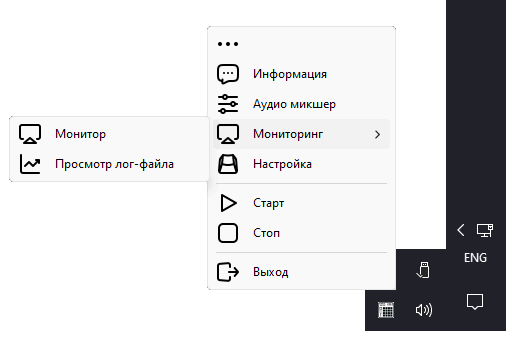

### Соглашение о именовании MIDI портов

- Входной MIDI порт вы можете выбрать из списка, это можно сделать выбрав управление модулем «взаимодействие с MIDI устройствами».
- Автоматически создаваемые выходные MIDI порты на которых формируются **MIDI-Mackie** нотации имеют имя составленное из порядкового номера входного порта и префикса **MIDI-MT-Mackie-Out-(номер)**.
- Имя MIDI прокси порта формируется аналогичным образом, префикс для него будет **MIDI-MT-Proxy-Out-(номер)**.

  Например:

```yaml
Входной MIDI порт:  W-FADER                // MIDI контроллер
Выходной MIDI порт: MIDI-MT-Mackie-Out-1   // Premiere Pro (MIDI Mackie) порт
Прокси MIDI порт:   MIDI-MT-Proxy-Out-1    // Для подключения любого приложения
                                           // для параллельного управления с контроллера
```

Точное названия портов можно получить использовав пункт меню «**Мониторинг**» > «**Просмотр лог-файла**» > «**Плагины**» > «**Статистика плагинов**», при запущенном **MIDI-MT**.

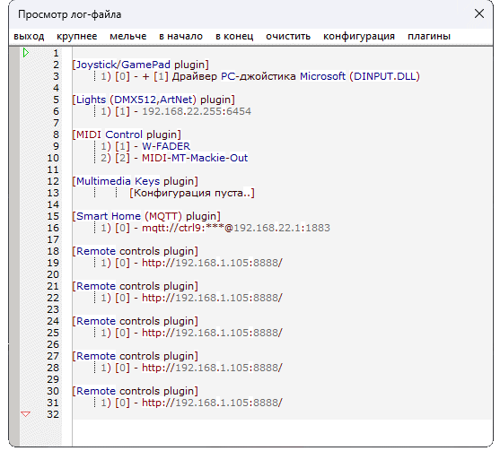

Статистика плагинов MIDI-MT

### Поведение

- отмечен пункт «**авто старт**», диалог не будет ожидать нажатия кнопки «**Старт**», а в момент открытия запустит транслятор.
- отмечен пункт «**старт при загрузке**», в момент автоматического запуска приложения при загрузке операционной системы приложение **MIDI-MT** будет загружено. Если пункт «**авто старт**» активен, транслятор будет запущен автоматически.
- пункт «**записывать лог**» отвечает за запись происходящих событий в файл, для возможного дальнейшего анализа отказа/отключения/подключения MIDI оборудования.
- подробнее о элементах управления и поведении приложения можно прочесть на страницах «Настройки» и «Файлы конфигурации».

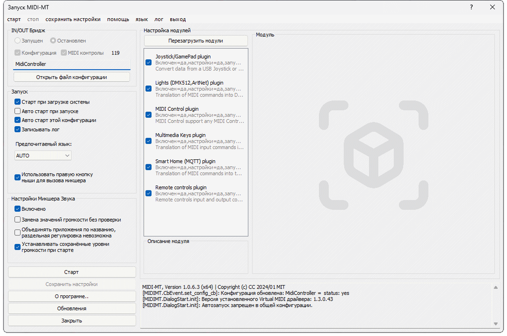

### Операции

Если пункт «**авто старт**» **не** активирован, для запуска транслятора, в главном меню необходимо нажать кнопку «**Старт**».  
Внесённые изменения можно сохранить в конфигурационном файле с помощью кнопки «**Сохранить настройки**».  
В дальнейшем эти настройки будут применяться автоматически.  
Для выхода из диалога «**Старт**», как и из других диалогов, нажмите кнопку «**Закрыть**».  
Кнопки «**О программе**» и «**Обновления**», интуитивно понятны и не требуют объяснений.

[figure not shown]

При запуске, есть возможность использовать ключи командной строки. Подробно о синтаксисе ключей описано в разделе - Параметры командной строки.